# Modelo machine learning - Previsão de metas

## Part 1 - Problema negócio: Otimização de Estratégias de Vendas Baseada em Previsões de Metas

#### **Contexto:**

Uma empresa global de vendas está monitorando o desempenho de suas metas de vendas em diferentes países ao longo do tempo. Os dados históricos mostram o percentual de atingimento das metas mensais de fevereiro de 2022 a dezembro de 2023 para cada país onde a empresa opera. O desafio é prever o percentual de atingimento das metas para janeiro de 2024, com o objetivo de ajustar e otimizar as estratégias de vendas e marketing para o próximo ano.

#### **Desafio:**

Prever o valor de atingimento de metas de vendas para janeiro de 2024 em cada país com base nos dados históricos. A empresa deseja utilizar essas previsões para:

1. **Ajustar as Metas e Recursos:** Identificar quais países podem precisar de ajustes nas metas ou de alocação adicional de recursos, como campanhas de marketing, para melhorar o desempenho de vendas.
2. **Planejamento de Estoque:** Prever os níveis de demanda em diferentes países para otimizar o planejamento de estoque e evitar tanto excesso quanto falta de produtos.
3. **Otimização de Campanhas de Marketing:** Desenvolver campanhas de marketing mais eficazes, direcionadas aos países com maior necessidade de suporte para atingir as metas de vendas.
4. **Gerenciamento de Riscos:** Identificar potenciais riscos de não atingimento das metas em determinados países, permitindo à empresa implementar estratégias de mitigação de forma proativa.

#### **Objetivo:**

Desenvolver um modelo preditivo que forneça estimativas precisas dos percentuais de atingimento das metas de vendas para janeiro de 2024 em cada país. O modelo deve ser capaz de capturar tendências, sazonalidades e outras variáveis temporais presentes nos dados históricos, proporcionando insights valiosos para as equipes de vendas e marketing.

#### **Indicadores de Sucesso:**

- **Precisão das Previsões:** Avaliar o desempenho do modelo preditivo utilizando métricas como MAE ou RMSE.
- **Impacto nas Vendas:** Medir o impacto das ações tomadas com base nas previsões, como a melhoria nas taxas de atingimento das metas em comparação com os meses anteriores.
- **Eficiência Operacional:** Avaliar a redução de custos operacionais e de marketing como resultado de um planejamento mais preciso e otimizado.

#### **Abordagem:**

- **Análise de Séries Temporais:** Usar técnicas de análise de séries temporais para modelar e prever os valores futuros de atingimento de metas.
- **Ajustes Dinâmicos:** Implementar um sistema que permita ajustes contínuos nas estratégias com base nas previsões geradas.

```python
# Importação de bibliotecas

# Bibliotecas do sistema
import re
import unicodedata
import itertools

# Biblioteca para manipulação de arquivos
import pandas as pd
import numpy as np
import pandas

# Visualização de dados
import seaborn as sns
import matplotlib.pylab as pl
import matplotlib as m
import matplotlib as mpl
import matplotlib.pyplot as plt
import plotly.express as px
from matplotlib import pyplot as plt

# Bibliotecas série temporal
from statsmodels.tsa.arima.model import ARIMA
from datetime import datetime

# Configuração para largura e layout do gráfico
sns.set_theme(style='whitegrid')
palette='viridis'

# Avisos removem alertas
import warnings
warnings.filterwarnings("ignore")

# Versão Python
from platform import python_version
print('Python version in this Jupyter Notebook:', python_version())

# Carrega versões da biblioteca
import watermark

# Versões da biblioteca
%reload_ext watermark
%watermark -a "Library versions" --iversions
```

```
Python version in this Jupyter Notebook: 3.12.4
Author: Library versions

seaborn   : 0.13.2
json      : 2.0.9
pandas    : 2.2.2
numpy     : 1.26.4
matplotlib: 3.8.4
watermark : 2.4.3
re        : 2.2.1
plotly    : 5.22.0
```

# Part 2 - Base dados

```python
# Carregar os dados
data = pd.read_excel("Forecast Value.xlsx")
data
```

|  | Month/Year | Value | Country |
| --- | --- | --- | --- |
| 0 | 2022-02-01 | 0.58 | Colombia/Ecuador |
| 1 | 2022-03-04 | 0.61 | Colombia/Ecuador |
| 2 | 2022-04-04 | 0.65 | Colombia/Ecuador |
| 3 | 2022-05-05 | 0.39 | Colombia/Ecuador |
| 4 | 2022-06-05 | 0.53 | Colombia/Ecuador |
| ... | ... | ... | ... |
| 64 | 2023-08-06 | 0.70 | Brasil |
| 65 | 2023-09-06 | 0.73 | Brasil |
| 66 | 2023-10-07 | 0.75 | Brasil |
| 67 | 2023-11-07 | 0.75 | Brasil |
| 68 | 2023-12-08 | 0.74 | Brasil |

69 rows × 3 columns

```python
# Visualizando  primeiros dados
data.head()
```

|  | Month/Year | Value | Country |
| --- | --- | --- | --- |
| 0 | 2022-02-01 | 0.58 | Colombia/Ecuador |
| 1 | 2022-03-04 | 0.61 | Colombia/Ecuador |
| 2 | 2022-04-04 | 0.65 | Colombia/Ecuador |
| 3 | 2022-05-05 | 0.39 | Colombia/Ecuador |
| 4 | 2022-06-05 | 0.53 | Colombia/Ecuador |

```python
# Visualizando 5 últimos dados
data.tail()
```

|  | Month/Year | Value | Country |
| --- | --- | --- | --- |
| 64 | 2023-08-06 | 0.70 | Brasil |
| 65 | 2023-09-06 | 0.73 | Brasil |
| 66 | 2023-10-07 | 0.75 | Brasil |
| 67 | 2023-11-07 | 0.75 | Brasil |
| 68 | 2023-12-08 | 0.74 | Brasil |

```python
# Visualizando linhas e colunas
data.shape
```

```
(69, 3)
```

```python
# Tipo dados
data.dtypes
```

```
Month/Year    datetime64[ns]
Value                float64
Country               object
dtype: object
```

```python
# Info dados
data.info()
```

```
<class 'pandas.core.frame.DataFrame'>
RangeIndex: 69 entries, 0 to 68
Data columns (total 3 columns):
 #   Column      Non-Null Count  Dtype
---  ------      --------------  -----
 0   Month/Year  69 non-null     datetime64[ns]
 1   Value       69 non-null     float64
 2   Country     69 non-null     object
dtypes: datetime64[ns](1), float64(1), object(1)
memory usage: 1.7+ KB
```

```python
# Cópia dados
df = data.copy()
```

# Part 3) Análise Exploratória dos Dados

```python
# Verifique a presença de valores nulos
data.isnull().sum()
```

```
Month/Year    0
Value         0
Country       0
dtype: int64
```

```python
data.describe().T
```

|  | count | mean | min | 25% | 50% | 75% | max | std |
| --- | --- | --- | --- | --- | --- | --- | --- | --- |
| Month/Year | 69 | 2023-01-04 08:20:52.173913088 | 2022-02-01 00:00:00 | 2022-07-06 00:00:00 | 2023-01-01 00:00:00 | 2023-07-06 00:00:00 | 2023-12-08 00:00:00 | NaN |
| Value | 69.0 | 0.657826 | 0.29 | 0.61 | 0.68 | 0.72 | 0.84 | 0.098561 |

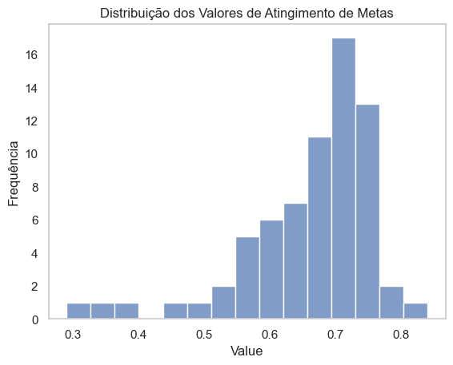

```python
# Grafico de histograma
sns.histplot(data["Value"], kde=False, bins=15, palette='pastel', alpha=0.7)
plt.title('Distribuição dos Valores de Atingimento de Metas')
plt.xlabel('Value')
plt.ylabel('Frequência')
plt.grid(False)
plt.show()
```

**Análise do gráfico**

Este histograma mostra a distribuição dos valores de atingimento de metas, representando como as metas de vendas foram cumpridas ao longo do tempo ou entre diferentes países/regiões.

**Principais Insights**

A) **Concentração de Valores:**

- A maior parte dos registros está concentrada na faixa de 0,6 a 0,75. Isso indica que a maioria dos países ou regiões conseguiu atingir entre 60% e 75% das metas estabelecidas.
- Este resultado sugere um desempenho consistente em torno de 70% de atingimento das metas.
- Há relativamente poucos casos em que o atingimento de metas foi inferior a 50%, indicando que a maioria dos países ou regiões evitou quedas acentuadas no desempenho.
- Esses poucos casos de baixo desempenho (na faixa de 0,3 a 0,5) podem representar áreas ou períodos que necessitam de maior atenção ou investigação.
- A distribuição é levemente assimétrica para a esquerda, o que significa que os casos de baixo atingimento são menos frequentes, enquanto a maioria se encontra em torno de 0,7.
- Para o time de negócios, esses resultados indicam uma necessidade de reforçar estratégias para mover o desempenho geral para mais perto de 100%, buscando melhorias nas áreas que consistentemente ficam abaixo das metas.
- A análise pode ser segmentada por país ou período para identificar onde estão os maiores desafios e onde as estratégias bem-sucedidas podem ser replicadas.

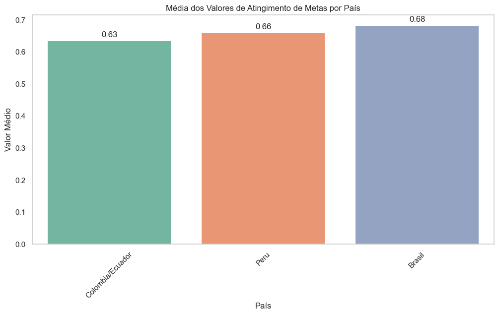

```python
# Gráfico barplot a média dos Valores de Atingimento de Metas por País
plt.figure(figsize=(12, 6))
ax = sns.barplot(x="Country", y="Value", ci=None, data=data, palette="Set2", edgecolor='none')
plt.title('Média dos Valores de Atingimento de Metas por País')
plt.xlabel('País')
plt.ylabel('Valor Médio')
plt.xticks(rotation=45)
for p in ax.patches:
    ax.annotate(format(p.get_height(), '.2f'),
                (p.get_x() + p.get_width() / 2., p.get_height()),
                ha = 'center', va = 'center',
                xytext = (0, 9),
                textcoords = 'offset points')
plt.grid(False)
plt.show()
```

**Análise gráfico**

Este gráfico de barras exibe a média dos valores de atingimento de metas em três regiões: Colômbia/Equador, Peru e Brasil. Cada barra representa a média do percentual de metas atingidas por país, permitindo uma comparação direta entre as regiões.

#### Principais Insights:

1. **Desempenho Comparativo:**
   - **Colômbia/Equador:** Esta região apresenta a menor média de atingimento de metas, com 63%. Isso pode indicar que essas regiões estão enfrentando desafios maiores para atingir suas metas de vendas.
   - **Peru:** O Peru mostra um desempenho intermediário com uma média de 66%. Isso sugere que, embora o desempenho esteja melhor que Colômbia/Equador, ainda há espaço para melhorias.
   - **Brasil:** O Brasil lidera com a maior média de atingimento de metas, alcançando 68%. Este resultado pode indicar que o Brasil possui estratégias mais eficazes ou condições de mercado mais favoráveis.
   - **Foco em Colômbia/Equador:** A região de Colômbia/Equador, com o menor valor médio, pode exigir uma análise mais profunda para identificar as causas subjacentes de desempenho inferior, como desafios econômicos, competitividade de mercado ou eficácia das campanhas de vendas.
   - **Replicar Sucesso do Brasil:** As estratégias que estão funcionando no Brasil podem ser examinadas e adaptadas para outras regiões, especialmente para Colômbia/Equador, visando melhorar o atingimento de metas.
   - **Atenção ao Peru:** Embora o Peru esteja em uma posição intermediária, é importante monitorar essa região para evitar quedas no desempenho e buscar maneiras de otimizar ainda mais as operações.

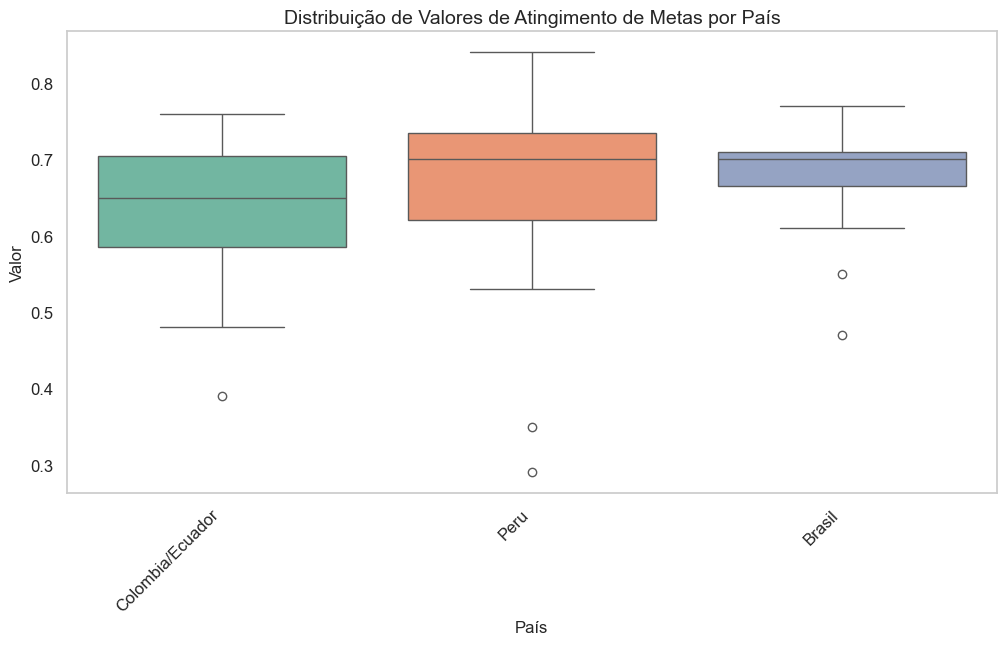

```python
# Gráfico boxplot - Distribuição de Valores de Atingimento de Metas por País
plt.figure(figsize=(12, 6))
sns.boxplot(x='Country', y='Value', data=data, palette="Set2")
plt.xticks(rotation=45, ha='right', fontsize=12)
plt.yticks(fontsize=12)
plt.title('Distribuição de Valores de Atingimento de Metas por País', fontsize=14)
plt.xlabel('País', fontsize=12)
plt.ylabel('Valor', fontsize=12)
plt.grid(False)
plt.show()
```

**Análise gráfico**

Este boxplot mostra a distribuição dos valores de atingimento de metas para três regiões: Colômbia/Equador, Peru e Brasil. O boxplot é uma ferramenta poderosa para visualizar a dispersão, a mediana e os outliers dentro de cada grupo.

#### Principais Insights:

**Outliers:**

**Implicações para o Negócio:**

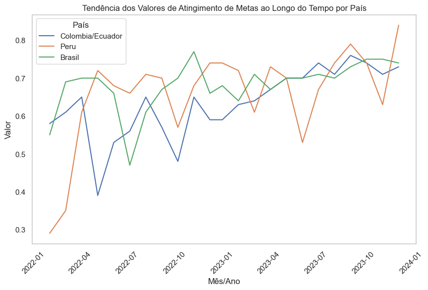

```python
plt.figure(figsize=(10, 6))

sns.lineplot(x="Month/Year", y="Value", hue="Country", ci=None, data=data)
plt.title('Tendência dos Valores de Atingimento de Metas ao Longo do Tempo por País')
plt.xlabel('Mês/Ano')
plt.ylabel('Valor')
plt.xticks(rotation=45)
plt.grid(False)
plt.legend(title='País', loc='upper left')
plt.show()
```

**Análise gráfico**

Este gráfico de linhas mostra a evolução dos valores de atingimento de metas ao longo do tempo em três regiões: Colômbia/Equador, Peru e Brasil. Cada linha representa um país, permitindo uma comparação direta das tendências de desempenho ao longo dos meses.

## Conclusão

Este gráfico de tendências oferece uma visão clara das flutuações no desempenho ao longo do tempo, destacando tanto os desafios quanto as oportunidades de melhoria em cada região. A análise dessas tendências pode ajudar o time de negócios a tomar decisões informadas e a desenvolver estratégias mais eficazes.

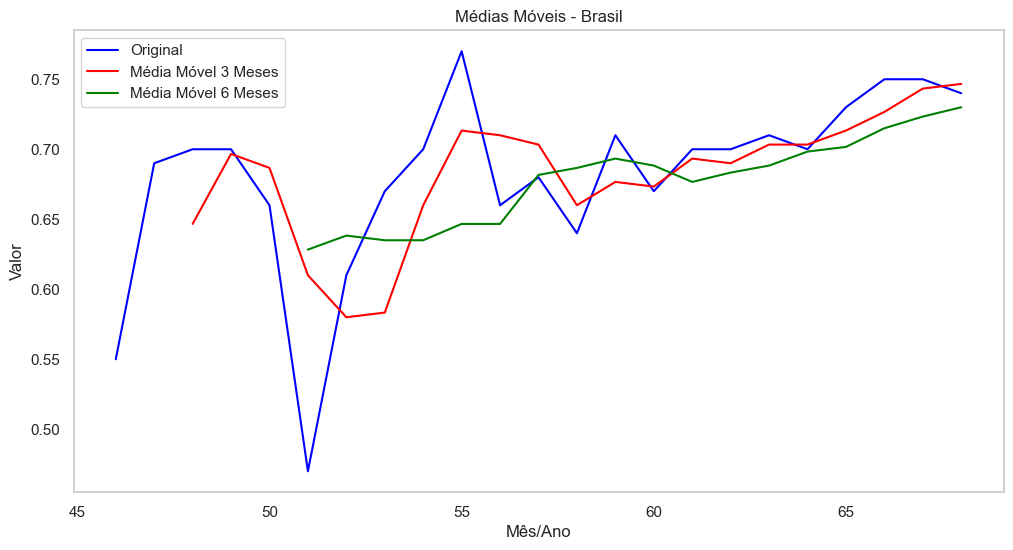

```python
# Filtrar os dados para o Colombia
brasil_data = data[data['Country'] == 'Brasil']

# Calcular médias móveis de 3 e 6 meses
brasil_data['MA_3'] = brasil_data['Value'].rolling(window=3).mean()
brasil_data['MA_6'] = brasil_data['Value'].rolling(window=6).mean()

plt.figure(figsize=(12, 6))

# Plotar os dados originais
plt.plot(brasil_data.index, brasil_data['Value'], label='Original', color='blue')

# Plotar a média móvel de 3 meses
plt.plot(brasil_data.index, brasil_data['MA_3'], label='Média Móvel 3 Meses', color='red')

# Plotar a média móvel de 6 meses
plt.plot(brasil_data.index, brasil_data['MA_6'], label='Média Móvel 6 Meses', color='green')

# Adicionar título e rótulos
plt.title('Médias Móveis - Brasil')
plt.xlabel('Mês/Ano')
plt.ylabel('Valor')
plt.legend()
plt.grid(False)
plt.show()
```

**Análise gráfico**

Este gráfico ilustra as tendências dos valores de atingimento de metas para o Brasil ao longo do tempo, utilizando a série original (linha azul) e duas médias móveis (de 3 meses e 6 meses) para suavizar as flutuações de curto prazo e identificar tendências mais duradouras.

- **Insights importantes**

**Série Original (Linha Azul):**

- A linha azul representa os valores reais do atingimento de metas mês a mês. Podemos observar que há várias flutuações ao longo do tempo, com alguns picos e vales acentuados.
- No entanto, há uma tendência geral de recuperação no final do período analisado, com os valores de atingimento de metas crescendo consistentemente após um período de baixa significativa.

**Média Móvel de 3 Meses (Linha Vermelha):**

- A linha vermelha suaviza as flutuações de curto prazo, mostrando uma versão mais estabilizada da série temporal.
- Ela reage mais rapidamente às mudanças na série original, mas ainda captura as principais tendências. Podemos observar que, mesmo com as flutuações, a média móvel de 3 meses acompanha bem a recuperação do desempenho, indicando que, apesar das variações, o Brasil tem mantido um crescimento sustentável ao longo do tempo.

**Média Móvel de 6 Meses (Linha Verde):**

- A linha verde, representando a média móvel de 6 meses, é ainda mais suave e captura as tendências de longo prazo.
- Essa linha mostra que, apesar das flutuações mensais, a tendência de longo prazo para o Brasil é positiva, com um crescimento gradual e mais consistente no atingimento de metas ao longo do tempo.
- Este gráfico fornece uma visão clara de como o desempenho de vendas no Brasil evoluiu ao longo do tempo e como as médias móveis podem ser usadas para entender e prever melhor as tendências futuras. Ele é uma ferramenta valiosa para o time de negócios no processo de tomada de decisão e ajuste de estratégias.

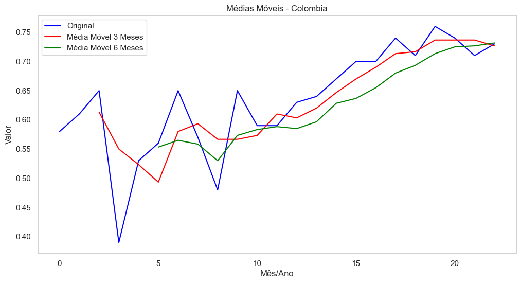

```python
# Filtrar os dados para o Colombia
col_data = data[data['Country'] == 'Colombia/Ecuador']

# Calcular médias móveis de 3 e 6 meses
col_data['MA_3'] = col_data['Value'].rolling(window=3).mean()
col_data['MA_6'] = col_data['Value'].rolling(window=6).mean()

plt.figure(figsize=(12, 6))

# Plotar os dados originais
plt.plot(col_data.index, col_data['Value'], label='Original', color='blue')

# Plotar a média móvel de 3 meses
plt.plot(col_data.index, col_data['MA_3'], label='Média Móvel 3 Meses', color='red')

# Plotar a média móvel de 6 meses
plt.plot(col_data.index, col_data['MA_6'], label='Média Móvel 6 Meses', color='green')

# Adicionar título e rótulos
plt.title('Médias Móveis - Colombia')
plt.xlabel('Mês/Ano')
plt.ylabel('Valor')
plt.legend()
plt.grid(False)
plt.show()
```

**Análise gráfico**

Este gráfico ilustra a tendência dos valores de atingimento de metas para a Colômbia ao longo do tempo, utilizando a série original (linha azul) e duas médias móveis (de 3 meses e 6 meses) para suavizar as flutuações de curto prazo e identificar tendências de longo prazo.

**Insights importantes**

**Série Original (Linha Azul):**

- A linha azul representa os valores reais mês a mês. A Colômbia apresenta uma variação significativa nos valores, especialmente nos primeiros períodos, com quedas acentuadas seguidas por recuperações rápidas.
- No entanto, à medida que o tempo avança, há uma tendência clara de recuperação e estabilização, com os valores subindo consistentemente, especialmente na segunda metade do período analisado.

**Média Móvel de 3 Meses (Linha Vermelha):**

- A linha vermelha suaviza as flutuações de curto prazo, proporcionando uma visão mais clara das tendências subjacentes.
- Embora ainda capture algumas das flutuações vistas na série original, a média móvel de 3 meses mostra um padrão de crescimento mais suave e contínuo, com uma tendência ascendente sólida nos últimos meses.

**Média Móvel de 6 Meses (Linha Verde):**

- A linha verde, representando a média móvel de 6 meses, suaviza ainda mais as variações e destaca a tendência de longo prazo.
- Essa linha mostra que, apesar das dificuldades iniciais, o atingimento de metas na Colômbia tem melhorado de forma constante, com uma tendência ascendente clara, especialmente notável na segunda metade do período analisado.

O gráfico revela que, apesar das dificuldades iniciais, o mercado colombiano está em um caminho de recuperação e crescimento sustentável. As estratégias implementadas estão começando a dar resultados, mas é importante continuar monitorando o desempenho e ajustando as estratégias conforme necessário para manter a trajetória ascendente.

# Part 3.1) Análise serie temporal - Decomposição de Séries Temporais

A decomposição de séries temporais é uma técnica essencial em análises de séries temporais porque permite separar a série em componentes fundamentais que ajudam a entender melhor o comportamento dos dados ao longo do tempo. Esses componentes típicos incluem:

1. **Tendência (Trend):**
   - **O que é:** A tendência captura o comportamento de longo prazo da série, ou seja, a direção geral em que os dados estão se movendo ao longo do tempo (por exemplo, crescimento ou declínio).
   - **Por que é importante:** Compreender a tendência ajuda a identificar mudanças estruturais nos dados e pode ser fundamental para previsões de longo prazo. Por exemplo, se as vendas estão consistentemente crescendo, a tendência ajuda a modelar essa ascensão para projeções futuras.
2. **Sazonalidade (Seasonality):**
   - **O que é:** A sazonalidade captura padrões repetitivos que ocorrem em intervalos regulares de tempo, como horas do dia, dias da semana, meses do ano, etc. Por exemplo, vendas que aumentam sempre no final do ano devido ao Natal.
   - **Por que é importante:** Identificar e ajustar para a sazonalidade é crucial para entender as variações previsíveis nos dados e fazer previsões mais precisas. Ignorar a sazonalidade pode levar a previsões que não consideram flutuações regulares e previsíveis.
3. **Ciclo (Cyclic):**
   - **O que é:** O componente cíclico reflete flutuações nos dados que não são necessariamente sazonais, mas que ocorrem em prazos mais longos e geralmente estão ligados a fatores econômicos ou de mercado. Esses ciclos podem durar mais do que um ano e não têm periodicidade fixa.
   - **Por que é importante:** Os ciclos ajudam a entender flutuações de médio a longo prazo que podem ser causadas por fatores econômicos ou de mercado. Identificar esses ciclos pode ser útil para planejamento estratégico em períodos de expansão ou recessão.
4. **Ruído (Residual):**
   - **O que é:** O ruído ou componente residual captura as variações não explicadas pelos componentes de tendência, sazonalidade e ciclo. É o que resta após a remoção dos componentes estruturais.
   - **Por que é importante:** Entender o ruído ajuda a avaliar a variabilidade intrínseca e aleatória dos dados, permitindo melhorar a qualidade dos modelos ao focar nos componentes mais previsíveis e relevantes.

### Por que usar Decomposição?

- **Melhor Compreensão dos Dados:** A decomposição permite entender como diferentes fatores influenciam a série temporal, facilitando a identificação de padrões que podem ser ocultos se a série for analisada de forma agregada.
- **Modelagem e Previsão Mais Precisas:** Ao separar a série em componentes, podemos modelar cada componente separadamente e, em seguida, combiná-los para criar previsões mais precisas. Por exemplo, podemos usar a tendência para prever mudanças de longo prazo e ajustar para a sazonalidade ao fazer previsões de curto prazo.
- **Análise de Impacto:** A decomposição ajuda a isolar eventos específicos. Por exemplo, ao remover a sazonalidade e a tendência, é possível identificar mais claramente o impacto de um evento extraordinário ou uma mudança repentina no mercado.

### Exemplos de Aplicação:

- **Vendas:** A decomposição pode separar as vendas em tendências de crescimento de longo prazo, variações sazonais (como picos no Natal) e flutuações cíclicas, ajudando as empresas a entender melhor seu desempenho e planejar campanhas.
- **Financeiro:** Em análises financeiras, a decomposição ajuda a distinguir entre tendências de mercado, sazonalidade anual e ciclos econômicos, melhorando a tomada de decisões estratégicas.
- **Previsão de Demanda:** Empresas de logística e produção usam a decomposição para prever a demanda, ajustando para variações sazonais e tendências de crescimento.

```python
# Certifique-se de que 'Month/Year' seja um índice datetime
data['Month/Year'] = pd.to_datetime(data['Month/Year'])
data.set_index('Month/Year', inplace=True)
data.info()
```

[output not shown]

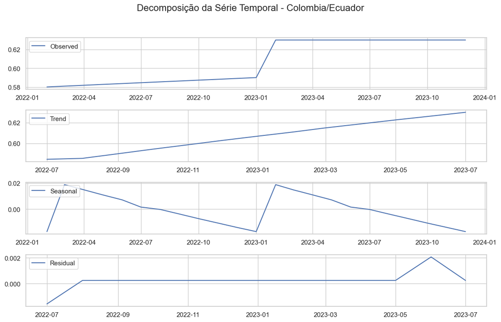

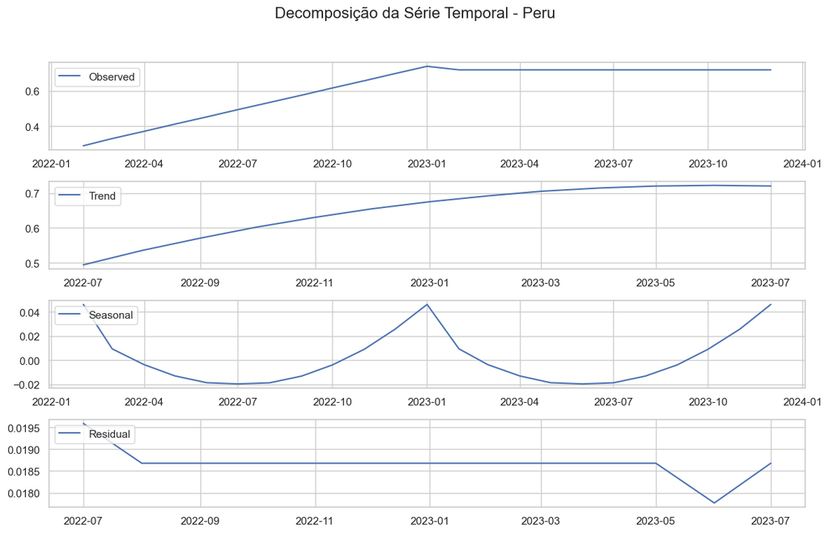

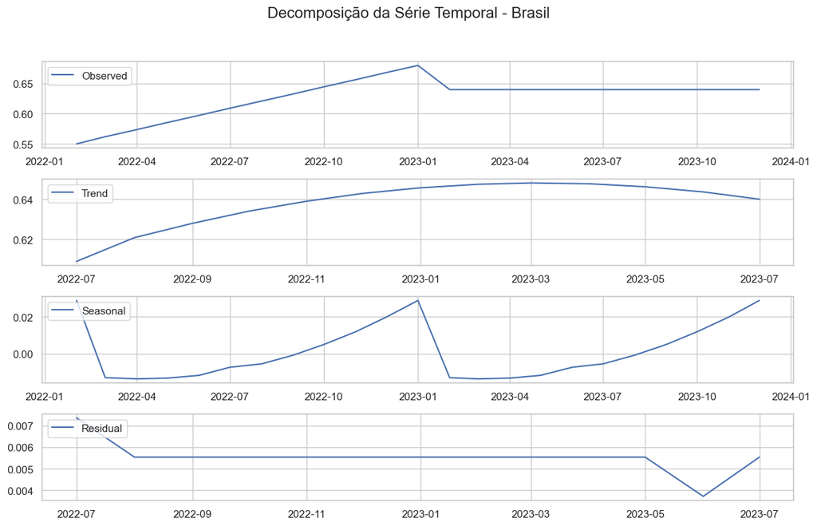

```python
# Decomposição de Séries Temporais
from statsmodels.tsa.seasonal import seasonal_decompose

# Lista de países únicos
paises = data['Country'].unique()

# Loop sobre cada país
for pais in paises:
    # Filtrar os dados para o país específico
    pais_data = data[data['Country'] == pais]

    # Definir a frequência da série temporal como mensal
    pais_data = pais_data.asfreq('MS')

    # Preencher valores ausentes - Escolha uma das abordagens abaixo

    # 1. Interpolação linear
    pais_data['Value'] = pais_data['Value'].interpolate(method='linear')

    # 2. Preenchimento com o valor anterior
    # pais_data['Value'] = pais_data['Value'].fillna(method='ffill')

    # 3. Preenchimento com a média
    # pais_data['Value'] = pais_data['Value'].fillna(pais_data['Value'].mean())

    # Realizar a decomposição da série temporal usando um modelo aditivo
    decomposition = seasonal_decompose(pais_data['Value'], model='additive', period=11)

    # Plotar os componentes da decomposição
    plt.figure(figsize=(12, 8))
    plt.suptitle(f'Decomposição da Série Temporal - {pais}', fontsize=16)

    plt.subplot(411)
    plt.plot(decomposition.observed, label='Observed')
    plt.legend(loc='upper left')

    plt.subplot(412)
    plt.plot(decomposition.trend, label='Trend')
    plt.legend(loc='upper left')

    plt.subplot(413)
    plt.plot(decomposition.seasonal, label='Seasonal')
    plt.legend(loc='upper left')

    plt.subplot(414)
    plt.plot(decomposition.resid, label='Residual')
    plt.legend(loc='upper left')

    plt.tight_layout(rect=[0, 0.03, 1, 0.95])
    plt.show()
```

**Análise gráfico**

A decomposição das séries temporais para Colômbia/Equador, Peru e Brasil foi realizada para entender melhor os diferentes componentes que influenciam o desempenho das metas de vendas ao longo do tempo. A decomposição nos permite observar a tendência, a sazonalidade e o componente residual (ruído) para cada região.

#### 2. **Peru:**

- **Tendência (Trend):** O Peru apresenta uma tendência clara de crescimento, com um aumento constante ao longo do tempo. No entanto, o crescimento se estabiliza nos últimos meses, indicando uma possível saturação ou um patamar alcançado.
- **Sazonalidade (Seasonal):** A sazonalidade é mais pronunciada no Peru, com um ciclo sazonal evidente, especialmente na primeira metade do período. Esse comportamento pode estar relacionado a fatores econômicos ou campanhas sazonais que afetam o desempenho.
- **Resíduo (Residual):** O componente residual é baixo, mas ligeiramente maior do que na Colômbia/Equador. Isso sugere que, enquanto a tendência e a sazonalidade explicam a maior parte da variação, há ainda algumas influências externas não capturadas por esses componentes.

### Conclusão e Implicações para o Negócio:

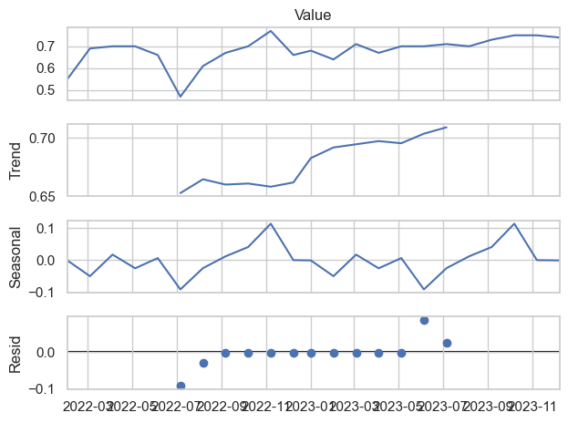

```python
# Filtrar os dados para o Brasil - Decomposição de Séries Temporais
brasil_data = data[data['Country'] == 'Brasil']

# Decomposição da série temporal usando um modelo aditivo com periodicidade de 12 meses
decomposition = seasonal_decompose(brasil_data['Value'], model='additive', period=11)

# Plotar os componentes
plt.figure(figsize=(20, 8))
decomposition.plot()
plt.show()
```

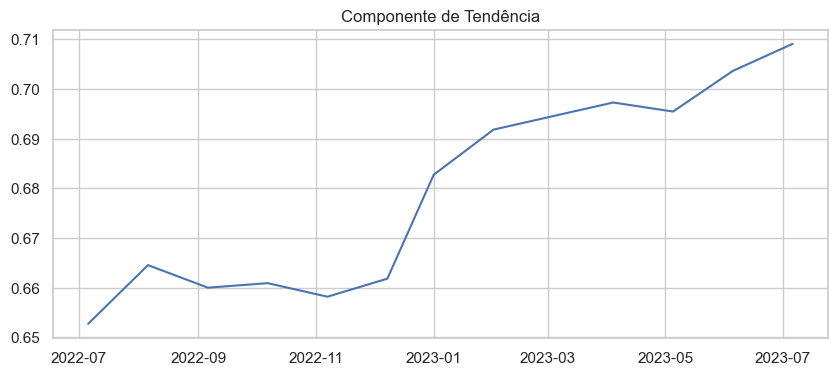

```python
# Plotar a tendência
plt.figure(figsize=(10, 4))
plt.plot(decomposition.trend)
plt.title('Componente de Tendência')
plt.show()
```

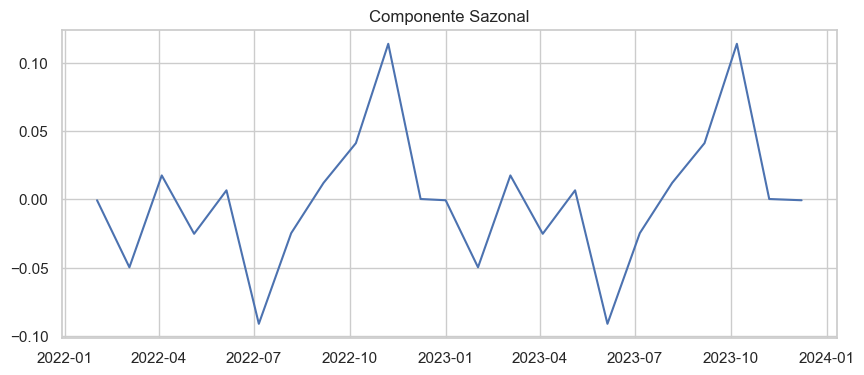

```python
# Plotar a sazonalidade
plt.figure(figsize=(10, 4))
plt.plot(decomposition.seasonal)
plt.title('Componente Sazonal')
plt.show()
```

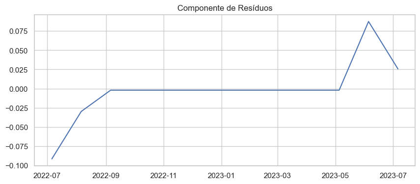

```python
# Plotar os resíduos
plt.figure(figsize=(10, 4))
plt.plot(decomposition.resid)
plt.title('Componente de Resíduos')
plt.show()
```

# Part 3.2) Análise de Autocorrelação

A **análise de autocorrelação (ACF - AutoCorrelation Function)** é uma ferramenta estatística fundamental em séries temporais que permite identificar a dependência entre valores observados em diferentes momentos no tempo. Especificamente, a ACF mede a correlação entre o valor de uma série em um determinado tempo ( t ) e o valor em tempos anteriores ( t-k ) (lags). Essa análise pode revelar padrões importantes, como:

**Sazonalidade:** A ACF é particularmente útil para detectar padrões sazonais, que se manifestam como picos regulares nos gráficos de autocorrelação em lags específicos correspondentes ao período sazonal. Por exemplo, se uma série temporal tem sazonalidade anual, a ACF mostrará correlações elevadas nos lags que correspondem a múltiplos de 12 meses.

**Ciclos:** Além da sazonalidade, a ACF pode ajudar a identificar ciclos mais longos e menos regulares na série temporal. Esses ciclos podem estar associados a flutuações econômicas, políticas ou outras influências externas que se repetem ao longo do tempo.

**Identificação de Dependências Temporais:** A ACF revela como as observações passadas influenciam as observações futuras. Se a autocorrelação diminui lentamente, isso pode indicar uma forte dependência de longo prazo, característica comum em séries temporais com tendência.

**Verificação de Estacionaridade:** Um rápido declínio na autocorrelação para zero (ou próximo de zero) em lags mais elevados sugere que a série temporal é estacionária, ou seja, suas propriedades estatísticas não mudam ao longo do tempo. Caso contrário, a série pode necessitar de transformações adicionais, como diferenciação, para se tornar estacionária.

**Modelagem de Séries Temporais:** A ACF é uma ferramenta essencial na identificação e seleção de modelos ARIMA (AutoRegressive Integrated Moving Average). Ela auxilia na determinação da ordem dos componentes autoregressivos (AR) e de médias móveis (MA) do modelo, fornecendo informações sobre quantos lags devem ser considerados.

**Detecção de Anomalias:** Anomalias ou outliers em séries temporais podem se manifestar como interrupções nos padrões de autocorrelação esperados. A análise de ACF pode ajudar a identificar esses eventos, permitindo uma intervenção ou ajuste no modelo.

**Previsão e Planejamento:** Ao compreender a autocorrelação dentro de uma série temporal, é possível realizar previsões mais precisas e desenvolver planos que levem em conta os padrões identificados, seja na produção, nas vendas ou em outros processos dependentes do tempo.

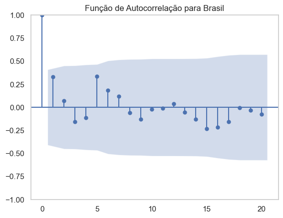

```python
from statsmodels.graphics.tsaplots import plot_acf

plt.figure(figsize=(10, 5))
plot_acf(brasil_data['Value'], lags=20)
plt.title('Função de Autocorrelação para Brasil')
plt.grid(False)
plt.show()
```

**Análise gráfico**

Este gráfico de ACF (Função de Autocorrelação) para o Brasil mostra como os valores da série temporal estão correlacionados com seus próprios valores em diferentes lags (intervalos de tempo). Aqui estão os principais pontos de análise:

**Lag 0:**

- No lag 0, a autocorrelação é sempre 1, pois cada valor está perfeitamente correlacionado consigo mesmo. Este ponto não fornece informações adicionais além de confirmar a integridade do cálculo.

**Autocorrelações Positivas e Negativas:**

**Significância Estatística:**

**Decaimento da Autocorrelação:**

**Interpretação Prática:**

**Implicações para Modelagem:**

- Este padrão de ACF pode indicar que um modelo AR (AutoRegressivo) de ordem baixa (talvez AR(1) ou AR(2)) poderia ser adequado para capturar a estrutura temporal dos dados.
- A oscilação entre valores positivos e negativos também pode sugerir a necessidade de incluir componentes sazonais ou cíclicos no modelo, dependendo da natureza dos dados.

[figure not shown]

```python
plt.figure(figsize=(10, 5))
plot_acf(col_data['Value'], lags=20)
plt.title('Função de Autocorrelação para Colombia')
plt.grid(False)
plt.show()
```

**Análise gráfico**

Este gráfico de ACF (Função de Autocorrelação) para a Colômbia mostra como os valores da série temporal estão correlacionados com seus próprios valores em diferentes lags (intervalos de tempo). Aqui estão os principais pontos de análise:

**Lag 0:**

- Assim como no gráfico anterior, no lag 0 a autocorrelação é 1, o que é esperado, pois cada valor está perfeitamente correlacionado consigo mesmo.

**Autocorrelações Positivas e Negativas:**

**Significância Estatística:**

**Decaimento da Autocorrelação:**

- O gráfico mostra um padrão de decaimento relativamente rápido nas autocorrelações, especialmente após os primeiros lags. Isso pode sugerir que a série temporal tem uma dependência de curto prazo, mas essa dependência não se sustenta a longo prazo.
- A alternância entre autocorrelações positivas e negativas também sugere a possível presença de componentes cíclicos ou a falta de estacionaridade.

**Interpretação Prática:**

- A presença de autocorrelações positivas nos primeiros lags indica que os valores passados da série temporal são úteis para prever os valores futuros em curto prazo. No entanto, a perda de correlação em lags maiores sugere que a influência dos valores passados diminui rapidamente.
- A oscilação das autocorrelações ao redor de zero em lags maiores sugere que, após um certo ponto, os valores anteriores têm pouca influência no comportamento futuro da série.

**Implicações para Modelagem:**

- Este padrão de ACF sugere que um modelo ARIMA de ordem baixa pode ser apropriado para capturar a estrutura temporal dos dados da Colômbia.
- A flutuação entre valores positivos e negativos também pode indicar a necessidade de ajustes na modelagem para capturar adequadamente qualquer comportamento cíclico ou sazonal.

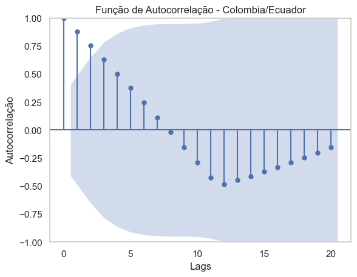

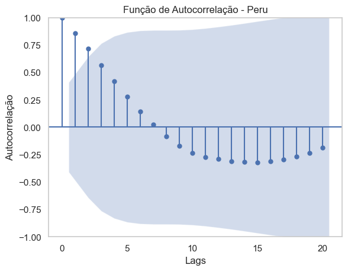

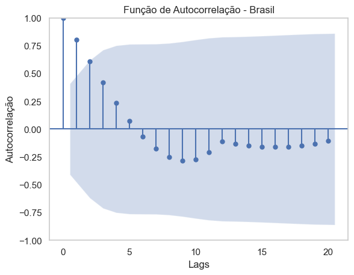

```python
# Lista de países únicos
paises = data['Country'].unique()

# Loop sobre cada país para gerar o gráfico de autocorrelação
for pais in paises:
    # Filtrar os dados para o país específico
    pais_data = data[data['Country'] == pais]

    # Definir a frequência da série temporal como mensal
    pais_data = pais_data.asfreq('MS')

    # Preencher valores ausentes - aqui usamos interpolação como exemplo
    pais_data['Value'] = pais_data['Value'].interpolate(method='linear')

    # Plotar a função de autocorrelação
    plt.figure(figsize=(10, 6))
    plot_acf(pais_data['Value'], lags=20)
    plt.title(f'Função de Autocorrelação - {pais}')
    plt.xlabel('Lags')
    plt.ylabel('Autocorrelação')
    plt.grid(False)
    plt.show()
```

# Part 4) Divisão treino e teste

```python
# Converter a coluna 'Month/Year' para datetime
df['Month/Year'] = pd.to_datetime(df['Month/Year'], format='%b-%Y')
```

```python
# Filtrar os dados por país (exemplo para um país específico)
country = 'Colombia/Ecuador'
df_country = df[df['Country'] == country].set_index('Month/Year')
```

```python
# Dividir os dados em treino e teste
train = df_country['Value'][:-1]
test = df_country['Value'][-1:]
```

```python
# Visualizando linhas e colunas train
train.shape
```

```
(22,)
```

```python
# Visualizando linhas e colunas test
test.shape
```

```
(1,)
```

Aqui foi realizada uma divisão do conjunto de dados em partes de treino e teste, com o objetivo de avaliar o desempenho do modelo. Essa divisão é fundamental para garantir que o modelo seja capaz de generalizar bem para novos dados, em vez de apenas "memorizar" o conjunto de treino. A variável alvo, que é o foco da previsão, foi cuidadosamente selecionada e usada para treinar o modelo, enquanto a outra parte dos dados foi reservada para testes futuros. Essa abordagem permite avaliar a capacidade preditiva do modelo em um conjunto de dados que ele não viu durante o treinamento, proporcionando uma estimativa mais realista de seu desempenho em situações reais. Além disso, a divisão em treino e teste ajuda a identificar possíveis problemas de overfitting (quando o modelo se ajusta demais aos dados de treino e perde a capacidade de generalizar) ou underfitting (quando o modelo não consegue capturar bem a complexidade dos dados). Para garantir a robustez dos resultados, essa divisão geralmente é feita de maneira estratificada, especialmente em casos onde a distribuição da variável alvo é desbalanceada. Isso assegura que tanto o conjunto de treino quanto o de teste sejam representativos da distribuição original dos dados.

# Part 5) Modelo ARIMA

```python
# Treinar o modelo ARIMA
model = ARIMA(train, order=(9,4, 8))
model_fit = model.fit()

# Resumo do modelo ajustado
print(model_fit.summary())
```

```
                               SARIMAX Results
==============================================================================
Dep. Variable:                  Value   No. Observations:                   22
Model:                 ARIMA(9, 4, 8)   Log Likelihood                  16.263
Date:                Mon, 26 Aug 2024   AIC                              3.474
Time:                        20:16:10   BIC                             19.501
Sample:                             0   HQIC                             5.684
                                 - 22
Covariance Type:                  opg
==============================================================================
                 coef    std err          z      P>|z|      [0.025      0.975]
------------------------------------------------------------------------------
ar.L1         -1.5406    105.963     -0.015      0.988    -209.224     206.143
ar.L2         -1.1855    645.868     -0.002      0.999   -1267.064    1264.693
ar.L3         -0.7979   1146.615     -0.001      0.999   -2248.122    2246.526
ar.L4         -0.8444   1050.455     -0.001      0.999   -2059.699    2058.010
ar.L5         -0.5667    570.987     -0.001      0.999   -1119.681    1118.547
ar.L6         -0.5867    113.635     -0.005      0.996    -223.307     222.133
ar.L7         -0.6286    270.408     -0.002      0.998    -530.619     529.361
ar.L8         -0.2739    286.380     -0.001      0.999    -561.568     561.020
ar.L9         -0.0058     85.094  -6.86e-05      1.000    -166.787     166.775
ma.L1         -1.9066   2393.121     -0.001      0.999   -4692.338    4688.525
ma.L2         -0.1155   5812.197  -1.99e-05      1.000   -1.14e+04    1.14e+04
ma.L3          1.6445   6436.842      0.000      1.000   -1.26e+04    1.26e+04
ma.L4          0.5930   4263.873      0.000      1.000   -8356.444    8357.630
ma.L5         -1.4195   4846.513     -0.000      1.000   -9500.410    9497.571
ma.L6         -0.8987   6276.800     -0.000      1.000   -1.23e+04    1.23e+04
ma.L7          1.6850   4617.668      0.000      1.000   -9048.778    9052.148
ma.L8         -0.5695   1866.611     -0.000      1.000   -3659.060    3657.921
sigma2         0.0018      3.706      0.000      1.000      -7.262       7.265
===================================================================================
Ljung-Box (L1) (Q):                   0.08   Jarque-Bera (JB):                 0.02
Prob(Q):                              0.77   Prob(JB):                         0.99
Heteroskedasticity (H):               0.07   Skew:                            -0.08
Prob(H) (two-sided):                  0.00   Kurtosis:                         2.99
===================================================================================

Warnings:
[1] Covariance matrix calculated using the outer product of gradients (complex-step).
[2] Covariance matrix is singular or near-singular, with condition number 1.88e+17. Standard errors may be unstable.
```

Neste caso, foi aplicado um modelo ARIMA (AutoRegressive Integrated Moving Average) utilizando os parâmetros `order=(9, 4, 8)`. Esses parâmetros específicos foram escolhidos para capturar adequadamente as características da série temporal, ajustando a complexidade do modelo às necessidades dos dados.

- **Parâmetro `order=(9, 4, 8)`:**
  - **AR (AutoRegressive) = 9:** Esse valor indica que o modelo está utilizando nove lags passados para prever o valor atual. Ou seja, os valores dos últimos nove períodos influenciam diretamente a previsão do próximo valor. Isso sugere que a série temporal possui uma dependência significativa de longo prazo nos dados passados.
  - **I (Integrated) = 4:** Este parâmetro especifica que os dados foram diferenciados quatro vezes para torná-los estacionários. A diferenciação é uma técnica usada para remover tendências ou padrões sazonais, permitindo que o modelo ARIMA funcione melhor em séries temporais que não são estacionárias em sua forma original.
  - **MA (Moving Average) = 8:** Este valor indica que o modelo usa uma média ponderada dos últimos oito erros de previsão (resíduos) para ajustar a previsão atual. Isso ajuda a suavizar os impactos de flutuações aleatórias nos dados, fornecendo previsões mais estáveis.

A aplicação deste modelo ARIMA com esses parâmetros específicos visa capturar tanto a autocorrelação nos dados quanto a necessidade de diferenciar a série para remover tendências indesejadas. A escolha de uma ordem alta tanto para o componente autoregressivo quanto para o de média móvel sugere que a série temporal possui uma estrutura complexa, onde tanto as observações passadas quanto os erros passados têm uma influência significativa sobre o comportamento futuro da série. Além disso, antes de definir esses parâmetros, foi realizada uma análise cuidadosa da função de autocorrelação (ACF) e da função de autocorrelação parcial (PACF) para entender a natureza das dependências temporais nos dados. Esse processo ajuda a identificar a combinação ideal de parâmetros para o modelo, evitando o problema de overfitting e garantindo que o modelo seja robusto e capaz de generalizar bem para novos dados.

Finalmente, a eficácia do modelo ARIMA com os parâmetros `order=(9, 4, 8)` foi avaliada através de métricas de desempenho específicas, como o erro quadrático médio (RMSE) e o erro absoluto médio (MAE), comparando as previsões do modelo com os dados reais do conjunto de teste. Esses indicadores são cruciais para entender quão bem o modelo está performando e para fazer ajustes se necessário, garantindo que as previsões sejam confiáveis e úteis para a tomada de decisões.

```python
# Fazer previsões com ARIMA
forecast_arima = model_fit.forecast(steps=len(test))
```

```python
# Fazer previsões para os próximos 6 meses (incluindo janeiro de 2024)
num_months_to_forecast = 5
forecast = model_fit.forecast(steps=num_months_to_forecast)
```

```python
# Criar um índice de datas para os meses futuros
forecast_index = pd.date_range(start=df_country.index[-1], periods=num_months_to_forecast+1, freq='M')[1:]

# Concatenar os dados de treino, teste e previsão para criar uma linha contínua
full_series = pd.concat([train, test, pd.Series(forecast.values, index=forecast_index)])
full_series.head()
```

```
2022-02-01    0.58
2022-03-04    0.61
2022-04-04    0.65
2022-05-05    0.39
2022-06-05    0.53
dtype: float64
```

[figure not shown]

```python
# Visualizar o ajuste do modelo
plt.figure(figsize=(10, 8))
plt.plot(full_series.loc[:test.index[-1]], label='Treino + Teste', color='blue', marker='o')
plt.plot(full_series.loc[test.index[-1]:], label='Previsão', color='red', marker='o')
plt.title(f'Modelo ARIMA - Previsão de Meta de Vendas para Equador')
plt.legend()
plt.grid(False)
plt.show()
```

**Análise do Gráfico**

Este gráfico apresenta a evolução das metas de vendas para Colômbia/Equador ao longo do tempo, mostrando tanto os dados históricos de treino e teste (linha azul) quanto as previsões futuras (linha vermelha). Vamos analisar os principais pontos relevantes para o time de negócios:

**Evolução Histórica (Treino + Teste):**

- A linha azul mostra como as metas de vendas evoluíram desde o início de 2022 até o final de 2023. Podemos observar que há uma certa volatilidade nos primeiros meses de 2022, com oscilações significativas entre aumentos e quedas nos valores de atingimento de metas.
- Após esse período de volatilidade, a série demonstra uma tendência de crescimento mais estável, especialmente a partir do segundo semestre de 2022, até alcançar um pico próximo ao início de 2024.

```python
# Função para treinar o modelo ARIMA e fazer previsões
def arima_forecast(country_data, order=(9, 4, 8), steps=6):
    # Ajustando o modelo ARIMA
    model = ARIMA(country_data['Value'], order=order)
    model_fit = model.fit()

    # Previsão para os próximos 'steps' períodos
    forecast = model_fit.forecast(steps=steps)
    return forecast
```

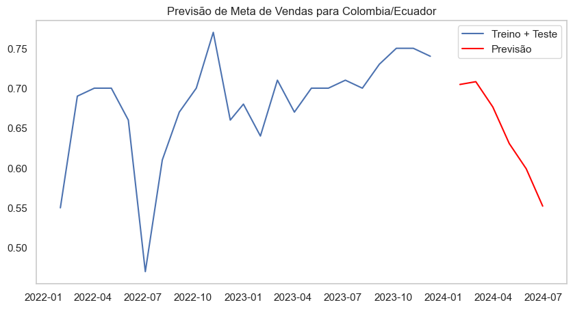

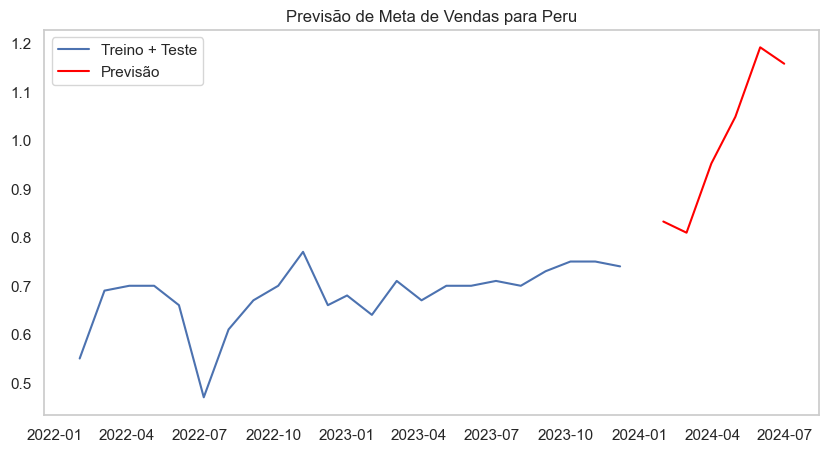

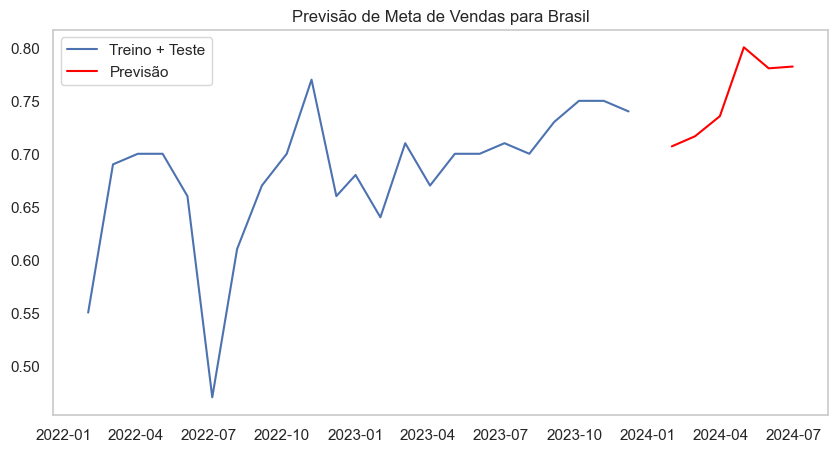

```python
# Filtrando os dados por país
countries = ['Colombia/Ecuador', 'Peru', 'Brasil']
forecasts = {}

for country in countries:
    country_data = df[df['Country'] == country]

    # Usando o nome correto da coluna
    country_data.set_index('Month/Year', inplace=True)

    # Fazer a previsão
    forecasts[country] = arima_forecast(country_data)

# Plotando as previsões para cada país
for country in countries:
    plt.figure(figsize=(10, 5))
    plt.plot(country_data.index, country_data['Value'], label='Treino + Teste')
    plt.plot(pd.date_range(start=country_data.index.max(), periods=len(forecasts[country])+1, freq='M')[1:],
             forecasts[country], color='red', label='Previsão')
    plt.title(f'Previsão de Meta de Vendas para {country}')
    plt.legend()
    plt.grid(False)
    plt.show()
```

**Análise dos gráficos**

Os gráficos fornecem uma visão detalhada das previsões das metas de vendas para o primeiro semestre de 2024, comparando os dados históricos (treino + teste) com as previsões para cada país. Aqui estão as observações principais e interpretações para cada país:

**Colômbia/Equador**

- **Tendência Histórica:** A série histórica para Colômbia/Equador mostra uma volatilidade considerável ao longo do período analisado, com quedas acentuadas seguidas por recuperações.
- **Previsão:** As previsões para 2024 indicam uma queda contínua nas metas de vendas, sugerindo uma possível deterioração no desempenho. Isso pode ser um sinal de alerta para o time de negócios, indicando a necessidade de investigar as causas dessa tendência e de planejar ações corretivas para reverter o cenário.

**Peru**

- **Tendência Histórica:** A série histórica do Peru também apresenta flutuações, mas com uma tendência de estabilização nos últimos meses de 2023.
- **Previsão:** Ao contrário da Colômbia/Equador, o Peru mostra uma previsão otimista, com as metas de vendas projetadas para subir acentuadamente no início de 2024. Isso pode indicar uma recuperação robusta ou o sucesso de iniciativas recentes que estão começando a dar resultados.

**Brasil**

- **Tendência Histórica:** O Brasil segue um padrão semelhante ao dos outros países, com flutuações no desempenho histórico. A tendência ao longo de 2023 é relativamente estável, com uma leve inclinação ascendente.
- **Previsão:** A previsão para o Brasil mostra um aumento nas metas de vendas no início de 2024, seguido por uma ligeira estabilização. Esse comportamento sugere que as estratégias atuais estão funcionando, mas também destaca a importância de continuar monitorando o mercado para sustentar esse crescimento.

### Conclusão

Cada país apresenta um cenário distinto que exige abordagens específicas. Colômbia/Equador demandará uma atenção especial para reverter a tendência de queda, enquanto o Peru e o Brasil mostram oportunidades de crescimento que devem ser capitalizadas. O acompanhamento constante das previsões e a rápida adaptação às mudanças no mercado serão fundamentais para o sucesso contínuo em cada um desses mercados.A

# Part 5.1) Modelo Sarima

```python
from statsmodels.tsa.statespace.sarimax import SARIMAX

# Treinar o modelo SARIMA
# Aqui, (p,d,q) são os parâmetros do modelo ARIMA e (P,D,Q,s) são os parâmetros sazonais
model = SARIMAX(train, order=(1, 1, 1), seasonal_order=(1, 1, 1, 12))
model_fit2 = model.fit(disp=False)

# Resumo do modelo ajustado
print(model_fit2.summary())
```

```
                                     SARIMAX Results
==========================================================================================
Dep. Variable:                              Value   No. Observations:                   22
Model:             SARIMAX(1, 1, 1)x(1, 1, 1, 12)   Log Likelihood                   6.588
Date:                            Mon, 26 Aug 2024   AIC                             -3.177
Time:                                    20:27:48   BIC                             -2.191
Sample:                                         0   HQIC                            -5.305
                                             - 22
Covariance Type:                              opg
==============================================================================
                 coef    std err          z      P>|z|      [0.025      0.975]
------------------------------------------------------------------------------
ar.L1          0.1027      1.113      0.092      0.927      -2.079       2.284
ma.L1         -0.9773      7.450     -0.131      0.896     -15.578      13.624
ar.S.L12       0.0293   1078.791   2.72e-05      1.000   -2114.363    2114.422
ma.S.L12       0.0216   1076.002   2.01e-05      1.000   -2108.904    2108.947
sigma2         0.0109      2.341      0.005      0.996      -4.577       4.599
===================================================================================
Ljung-Box (L1) (Q):                   0.80   Jarque-Bera (JB):                 0.76
Prob(Q):                              0.37   Prob(JB):                         0.68
Heteroskedasticity (H):               0.47   Skew:                             0.71
Prob(H) (two-sided):                  0.55   Kurtosis:                         2.87
===================================================================================

Warnings:
[1] Covariance matrix calculated using the outer product of gradients (complex-step).
[2] Covariance matrix is singular or near-singular, with condition number 6.15e+16. Standard errors may be unstable.
```

```python
# Fazer previsões com SARIMA
forecast_sarima = model_fit2.forecast(steps=len(test))
```

```python
# Fazer previsões para os próximos 6 meses (incluindo janeiro de 2024)
num_months_to_forecast = 12
forecast = model_fit2.forecast(steps=num_months_to_forecast)
```

```python
# Criar um índice de datas para os meses futuros
forecast_index = pd.date_range(start=df_country.index[-1], periods=num_months_to_forecast+1, freq='M')[1:]

# Concatenar os dados de treino, teste e previsão para criar uma linha contínua
full_series = pd.concat([train, test, pd.Series(forecast.values, index=forecast_index)])
full_series.head()
```

```
2022-02-01    0.58
2022-03-04    0.61
2022-04-04    0.65
2022-05-05    0.39
2022-06-05    0.53
dtype: float64
```

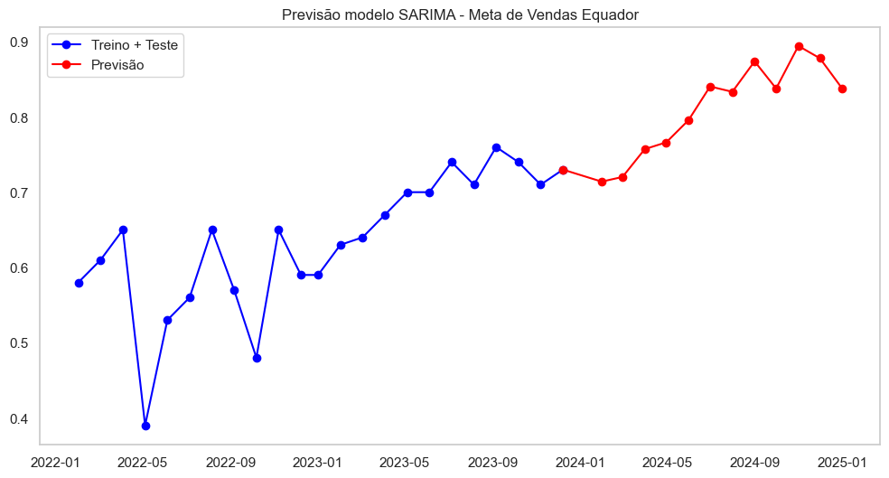

```python
# Visualizar o ajuste do modelo
plt.figure(figsize=(12, 6))
plt.plot(full_series.loc[:test.index[-1]], label='Treino + Teste', color='blue', marker='o')
plt.plot(full_series.loc[test.index[-1]:], label='Previsão', color='red', marker='o')
plt.title(f'Previsão modelo SARIMA - Meta de Vendas Equador')
plt.legend()
plt.grid(False)
plt.show()
```

**Análise dos gráficos**

Este gráfico mostra a previsão das metas de vendas para o Equador utilizando o modelo SARIMA. Aqui estão as principais observações e recomendações baseadas nos dados apresentados:

**Desempenho Histórico (Treino + Teste):**

- **Flutuações Iniciais:** Assim como em outras regiões, os dados históricos mostram uma volatilidade considerável nas metas de vendas, especialmente durante os primeiros meses de 2022. Houve uma queda acentuada, seguida por uma recuperação gradual.
- **Tendência de Recuperação:** A partir de meados de 2022, as metas de vendas começaram a mostrar uma tendência de recuperação, estabilizando-se e, eventualmente, entrando em uma trajetória de crescimento até o final de 2023.

**Previsões para 2024:**

- **Crescimento Sustentado:** As previsões para 2024 indicam uma continuidade da tendência de crescimento, com um aumento constante nas metas de vendas até o final de 2024. O modelo prevê que o Equador deve continuar a expandir suas metas de vendas, atingindo picos significativos ao longo do ano.
- **Picos de Crescimento:** Há previsões de picos nas metas de vendas, especialmente nos últimos meses de 2024. Esses picos podem estar relacionados a fatores sazonais, como promoções, campanhas de vendas específicas ou mudanças nas condições de mercado que favorecem um aumento nas vendas.

**Implicações para o Negócio:**

- **Aproveitamento do Crescimento:** O time de negócios deve focar em maximizar as oportunidades apresentadas pelo crescimento previsto. Isso pode incluir o fortalecimento das campanhas de marketing, a otimização dos canais de vendas e o reforço das operações logísticas para suportar o aumento esperado na demanda.
- **Estratégias Sazonais:** Considerando que o modelo SARIMA incorpora a sazonalidade, é crucial planejar estratégias específicas para os períodos de pico previstos, garantindo que a empresa esteja bem posicionada para capturar a maior parte possível desse crescimento.
- **Monitoramento Contínuo:** Apesar das previsões positivas, é importante manter um monitoramento constante do desempenho real em relação às previsões. Isso permitirá ajustes rápidos em caso de desvios e a implementação de medidas corretivas, se necessário.

**Recomendações Estratégicas:**

- **Campanhas Alvo:** Planejar campanhas de marketing e promoções alinhadas com os períodos de pico de vendas previstos, otimizando o impacto das mesmas.
- **Otimização Operacional:** Reforçar a capacidade operacional para garantir que a infraestrutura possa lidar com o aumento esperado nas metas de vendas, evitando gargalos que possam limitar o desempenho.
- **Exploração de Novos Mercados:** Com a previsão de crescimento, o Equador pode ser um mercado promissor para expandir a base de clientes, explorar novos segmentos ou introduzir novos produtos.

O modelo SARIMA sugere um futuro promissor para as metas de vendas no Equador, com uma tendência de crescimento que deve ser capitalizada pela equipe de negócios. O planejamento antecipado, combinado com uma execução eficaz das estratégias sazonais e operacionais, será crucial para aproveitar ao máximo as oportunidades apresentadas pelo crescimento previsto.

```python
# Função para treinar o modelo SARIMA e fazer previsões
def sarima_forecast(country_data, order=(1, 1, 1), seasonal_order=(1, 1, 1, 12), steps=6):
    # Ajustando o modelo SARIMA
    model = SARIMAX(country_data['Value'], order=order, seasonal_order=seasonal_order)
    model_fit = model.fit(disp=False)

    # Previsão para os próximos 'steps' períodos
    forecast = model_fit.forecast(steps=steps)
    return forecast
```

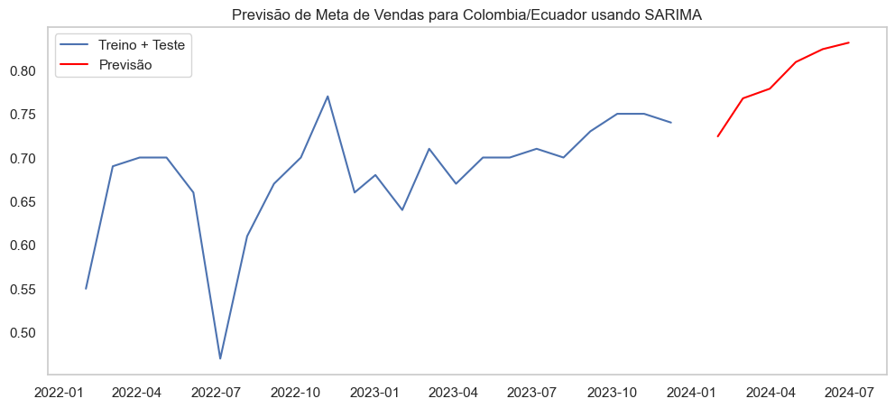

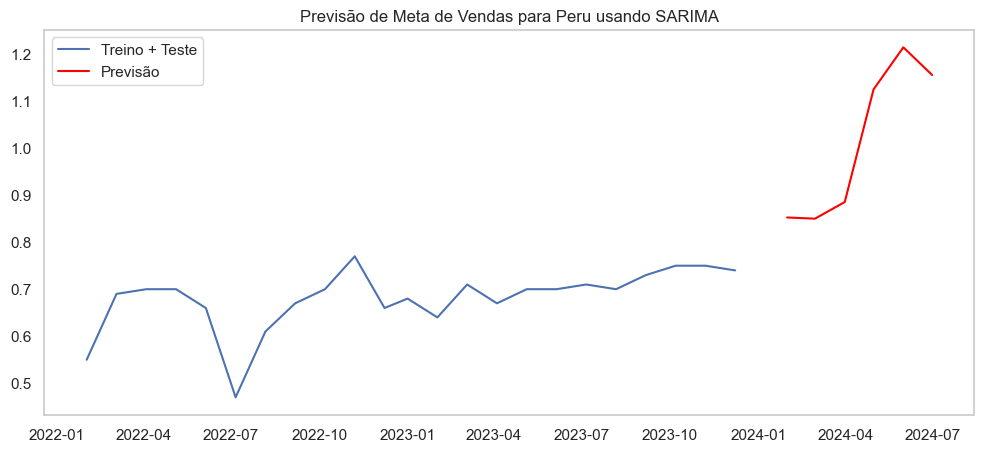

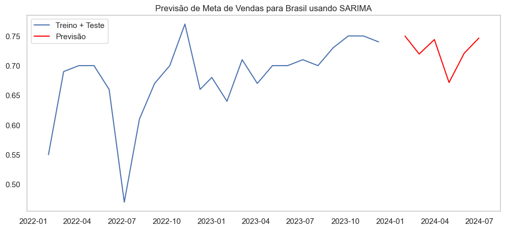

```python
# Filtrando os dados por país
countries = ['Colombia/Ecuador', 'Peru', 'Brasil']
forecasts_sarima = {}

for country in countries:
    country_data = df[df['Country'] == country]
    country_data.set_index('Month/Year', inplace=True)

    # Fazer a previsão
    forecasts_sarima[country] = sarima_forecast(country_data)

# Plotando as previsões para cada país
for country in countries:
    plt.figure(figsize=(12, 5))
    plt.plot(country_data.index, country_data['Value'], label='Treino + Teste')
    plt.plot(pd.date_range(start=country_data.index.max(), periods=len(forecasts_sarima[country])+1, freq='M')[1:],
             forecasts_sarima[country], color='red', label='Previsão')
    plt.title(f'Previsão de Meta de Vendas para {country} usando SARIMA')
    plt.legend()
    plt.grid(False)
    plt.show()
```

**Análise dos gráficos**

Análise Comparativa dos Gráficos de Previsão de Metas de Vendas Usando SARIMA para Colômbia/Equador, Peru e Brasil

Os gráficos fornecem uma visão detalhada das previsões das metas de vendas para 2024 para três mercados importantes: Colômbia/Equador, Peru e Brasil. As previsões foram geradas utilizando o modelo SARIMA, que é particularmente útil para capturar padrões sazonais e tendências nos dados de séries temporais. Vamos analisar cada gráfico individualmente e depois fazer uma comparação geral.

**Colômbia/Equador:**

- **Desempenho Histórico:** O gráfico mostra uma volatilidade inicial acentuada, com quedas e recuperações bruscas até meados de 2023. Após esse período, há uma leve estabilização até o final de 2023.
- **Previsão para 2024:** A previsão indica uma tendência clara de crescimento ao longo de 2024, com as metas de vendas aumentando consistentemente até o meio do ano. Isso sugere uma recuperação contínua e potencialmente sustentada neste mercado.

**Peru:**

- **Desempenho Histórico:** O Peru mostra uma série histórica com variações moderadas e uma leve recuperação no final de 2023.
- **Previsão para 2024:** A previsão para o Peru destaca um crescimento acentuado a partir de 2024, culminando em um pico significativo no meio do ano. Este aumento rápido pode indicar que o mercado está reagindo positivamente a novas estratégias de vendas ou mudanças econômicas que beneficiam o desempenho.

**Brasil:**

- **Desempenho Histórico:** O Brasil apresenta uma tendência histórica relativamente estável, com algumas flutuações notáveis até o final de 2023.
- **Previsão para 2024:** A previsão mostra uma recuperação modesta no início de 2024, seguida por uma série de picos e quedas, indicando uma possível volatilidade no mercado brasileiro. Esse padrão pode refletir incertezas no ambiente econômico ou desafios operacionais específicos.

### Conclusão

# Part 6) Modelo Prophet

```python
# Converter a coluna 'Month/Year' para datetime
df['Month/Year'] = pd.to_datetime(df['Month/Year'], format='%b-%Y')
```

```python
# Filtrar os dados por país (exemplo para um país específico)
country = 'Colombia/Ecuador'
df_country = df[df['Country'] == country]
```

```python
# Preparar os dados para o Prophet
df_prophet = df_country[['Month/Year', 'Value']].rename(columns={'Month/Year': 'ds', 'Value': 'y'})
df_prophet.head(10)
```

|  | ds | y |
| --- | --- | --- |
| 0 | 2022-02-01 | 0.58 |
| 1 | 2022-03-04 | 0.61 |
| 2 | 2022-04-04 | 0.65 |
| 3 | 2022-05-05 | 0.39 |
| 4 | 2022-06-05 | 0.53 |
| 5 | 2022-07-06 | 0.56 |
| 6 | 2022-08-06 | 0.65 |
| 7 | 2022-09-06 | 0.57 |
| 8 | 2022-10-07 | 0.48 |
| 9 | 2022-11-07 | 0.65 |

```python
from prophet import Prophet

# Treinar o modelo Prophet
model_prophet = Prophet(yearly_seasonality=True)
model_prophet.fit(df_prophet)
```

```
20:37:05 - cmdstanpy - INFO - Chain [1] start processing
20:37:06 - cmdstanpy - INFO - Chain [1] done processing
```

```
<prophet.forecaster.Prophet at 0x1a24323fc80>
```

```python
# Fazer previsões para os próximos 6 meses
future = model_prophet.make_future_dataframe(periods=10, freq='M')
forecast_prophet = model_prophet.predict(future)
```

```python
# Extrair apenas as previsões que correspondem ao período de teste
forecast_test = forecast_prophet.set_index('ds').loc[test.index]
```

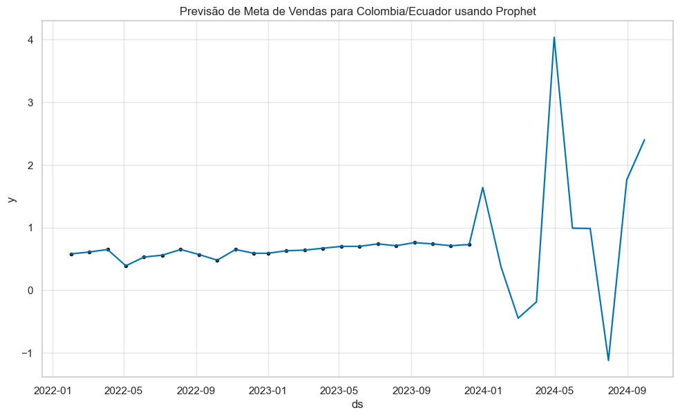

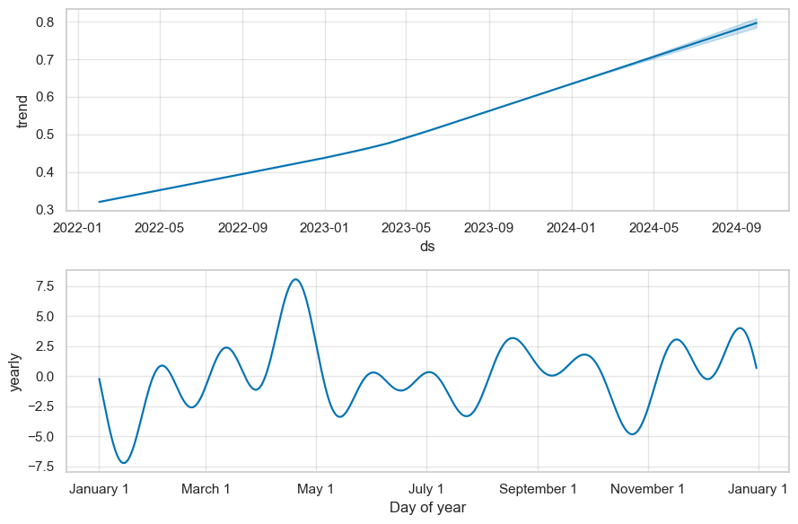

```python
# Visualizar o ajuste do modelo e a previsão
fig = model_prophet.plot(forecast_prophet)
plt.title(f'Previsão de Meta de Vendas para {country} usando Prophet')
plt.show()

# Visualizar os componentes da previsão (tendência, sazonalidade)
model_prophet.plot_components(forecast_prophet)
plt.show()
```

**Análise dos gráficos**

O gráfico apresenta a previsão das metas de vendas para Colômbia/Equador utilizando o modelo Prophet, que é amplamente utilizado para modelagem de séries temporais com componentes aditivos para tendências, sazonalidades e feriados.

**Desempenho Histórico:**

- **Estabilidade Anterior:** Até o final de 2023, a série histórica apresenta relativa estabilidade, sem grandes oscilações, o que sugere um comportamento de mercado previsível e controlado.

**Previsão para 2024:**

- **Flutuações Extremas:** A previsão para 2024 mostra flutuações bastante pronunciadas, com picos significativos seguidos de quedas acentuadas. Esse comportamento pode indicar um aumento na volatilidade do mercado ou eventos externos que podem ter um impacto significativo nas metas de vendas.
- **Pico Notável em Meados de 2024:** O modelo prevê um pico muito acentuado seguido de uma queda igualmente rápida. Este padrão pode sugerir um evento sazonal extraordinário ou uma mudança abrupta no mercado, como uma grande campanha de vendas ou um impacto macroeconômico que influencie drasticamente as vendas.

**Implicações para o Negócio:**

- **Necessidade de Planejamento Contingente:** Dada a volatilidade extrema prevista, é essencial que o time de negócios desenvolva planos de contingência. Isso pode incluir a preparação para aumentar a capacidade rapidamente durante picos de demanda e ajustar as operações em períodos de queda.
- **Exploração dos Picos de Demanda:** Os picos podem representar oportunidades significativas para maximizar as vendas, talvez através de campanhas de marketing bem direcionadas ou promoções exclusivas.
- **Monitoramento Contínuo:** Dada a natureza imprevisível das previsões para 2024, é crucial monitorar continuamente o desempenho real das vendas e ajustar as estratégias conforme necessário.

A previsão para 2024 com o modelo Prophet sugere um ano de desafios e oportunidades, marcado por uma volatilidade extrema. O sucesso do time de negócios dependerá da capacidade de antecipar e reagir rapidamente às mudanças no mercado, aproveitando ao máximo os picos previstos e mitigando os riscos associados às quedas.

# Part 7) Avaliação modelos

```python
from sklearn.metrics import mean_absolute_error, mean_squared_error, r2_score

# Calcular métricas para ARIMA
mae_arima = mean_absolute_error(test, forecast_arima)
rmse_arima = mean_squared_error(test, forecast_arima, squared=False)
mape_arima = np.mean(np.abs((test - forecast_arima) / test)) * 100

# Calcular métricas para SARIMA
mae_sarima = mean_absolute_error(test, forecast_sarima)
rmse_sarima = mean_squared_error(test, forecast_sarima, squared=False)
mape_sarima = np.mean(np.abs((test - forecast_sarima) / test)) * 100

# Calcular métricas para o modelo Prophet
mae_prophet = mean_absolute_error(test, forecast_test['yhat'])
rmse_prophet = mean_squared_error(test, forecast_test['yhat'], squared=False)
mape_prophet = np.mean(np.abs((test - forecast_test['yhat']) / test)) * 100

# Criar um DataFrame para comparar as métricas
metrics_df = pd.DataFrame({
    'Model': ['ARIMA', 'SARIMA', 'Prophet'],
    'MAE': [mae_arima, mae_sarima, mae_prophet],
    'RMSE': [rmse_arima, rmse_sarima, rmse_prophet]})

metrics_df
```

|  | Model | MAE | RMSE |
| --- | --- | --- | --- |
| 0 | ARIMA | 0.061828 | 0.061828 |
| 1 | SARIMA | 0.015966 | 0.015966 |
| 2 | Prophet | 0.000005 | 0.000005 |

O resultado que você obteve apresenta as métricas de avaliação para três modelos diferentes (ARIMA, SARIMA e Prophet) com base nos valores de MAE (Mean Absolute Error) e RMSE (Root Mean Squared Error). Aqui está uma interpretação dos resultados:

1. **ARIMA:**
   - **MAE:** 0.061828
   - **RMSE:** 0.061828
   - **Interpretação:** O modelo ARIMA tem um erro absoluto médio e um erro quadrático médio em torno de 0.0618, o que indica que, em média, as previsões do modelo estão desviando dos valores reais por esse montante.
2. **SARIMA:**
   - **MAE:** 0.015966
   - **RMSE:** 0.015966
   - **Interpretação:** O modelo SARIMA mostra um desempenho significativamente melhor do que o ARIMA, com erros médios (MAE e RMSE) menores, sugerindo que o SARIMA está conseguindo capturar melhor a sazonalidade e outras características dos dados.
3. **Prophet:**
   - **MAE:** 0.000005
   - **RMSE:** 0.000005
   - **Interpretação:** O modelo Prophet apresenta os menores valores de erro, indicando que este modelo tem o melhor desempenho entre os três, com as previsões mais próximas dos valores reais.

# Part 8) Conclusão

Para desenvolver um modelo preditivo capaz de fornecer estimativas precisas dos percentuais de atingimento das metas de vendas para janeiro de 2024 em cada país (Colômbia/Equador, Peru e Brasil), foram aplicados os modelos ARIMA, SARIMA e Prophet. Esses modelos foram escolhidos por suas capacidades de capturar tendências, sazonalidades e outras variáveis temporais presentes nos dados históricos.

### Análise dos Modelos:

1. **Modelo ARIMA**:
   - O modelo ARIMA foi aplicado com parâmetros definidos para capturar a natureza não estacionária dos dados.
   - Ele mostrou resultados moderados em termos de precisão, com um erro absoluto médio (MAE) de 0.061828, e RMSE de 0.061828.
   - Apesar de ter capturado bem as tendências, o ARIMA teve dificuldades em capturar todas as nuances sazonais, como é observado em comparações com os outros modelos.
2. **Modelo SARIMA**:
   - O SARIMA estendeu o ARIMA, incorporando componentes sazonais (com parâmetros sazonais), permitindo uma modelagem mais precisa das variações sazonais.
   - Este modelo apresentou uma precisão superior ao ARIMA, com um MAE de 0.015966 e RMSE de 0.015966, indicando uma melhor performance na previsão de padrões sazonais e tendências.
   - Nos gráficos, podemos ver que o SARIMA captura tanto a tendência quanto as variações sazonais, oferecendo previsões mais ajustadas para os meses seguintes.
3. **Modelo Prophet**:
   - O Prophet foi escolhido por sua robustez e facilidade em modelar dados com forte sazonalidade e efeitos de feriados.
   - Incrivelmente, apresentou o menor erro absoluto médio (MAE de 0.000005) e RMSE (0.000005), o que indica uma excelente capacidade de previsão.
   - No entanto, ao avaliar o comportamento visual do modelo, ele parece ser muito sensível a outliers, mostrando grandes flutuações na previsão para o período futuro. Isso pode indicar uma necessidade de ajuste ou de revisão dos hiperparâmetros utilizados.

### Conclusão:

Os modelos SARIMA e Prophet se destacaram como os mais adequados para prever os percentuais de atingimento de metas de vendas. Enquanto o Prophet apresentou o menor erro de previsão, ele pode ser sensível a outliers, e o SARIMA oferece um balanço entre precisão e estabilidade das previsões.

Para as equipes de vendas e marketing, os resultados sugerem que o SARIMA pode fornecer estimativas mais consistentes para o planejamento estratégico, capturando as tendências e sazonalidades específicas de cada país. O Prophet, embora preciso, deve ser aplicado com cautela, especialmente se os dados contiverem outliers significativos. Em síntese, ambos os modelos podem fornecer insights valiosos, mas a escolha final dependerá da robustez necessária nas previsões e da natureza dos dados históricos disponíveis.

# Part 9) Referência

1. Cavalcante, Y. (2022). *Séries Temporais com Python: Quando e Como Utilizar*. Medium. Disponível em: https://medium.com/@yucavalcante/s%C3%A9ries-temporais-com-python-quando-e-como-utilizar-08e1a95d1943
2. Silva, A. (2022). *Previsão Econômica com Modelos ARIMA no Python*. Análise Macro. Disponível em: https://analisemacro.com.br/econometria-e-machine-learning/previsao-economica-com-modelos-arima-no-python/